# Proyecto Final: Aplicaciones y Casos de Uso Empresarial

Movistar está preocupada por el aterrizaje de Netflix y por la oferta de Vodafone. Teme que algunos de sus clientes que tienen contratado MovistarPlus se vean atraídos por la nueva oferta de Vodafone. Os plantea la realización del diseño de una campaña de incentivos para mantener el mayor número de clientes en su empresa. En concreto, os piden:

1. Análisis de perfiles de posibles desertores. Se debe determinar un perfil del posible desertor, así como el perfil de aquel que no lo es. La empresa proporciona un dataset con un histórico de clientes que han dejado la empresa y los que no. A partir de él, se deben identificar los perfiles de aquellos que han abandonado la empresa para prever quiénes tienen una alta probabilidad de solicitar portabilidades a Vodafone. Los perfiles deben incluir los atributos relevantes y los valores correspondientes para dichos atributos.
2. Segmentación/creación de grupos entre los desertores y los no desertores. Se requiere agrupar a los usuarios dentro de cada clase en función de sus atributos más relevantes. Esta segmentación será clave para diseñar la campaña de incentivos.
3. Diseño de la campaña de incentivos. Es necesario identificar los incentivos que se ofrecerán a cada grupo. Para ello, habrá que estimar el valor derivado de la campaña en cada uno de los grupos de interés y simular los resultados de dicha campaña.

## Análisis de perfiles de desertores.

Para poder realizar el análsis de perfiles de desertores se va a hacer un análisis de Random Forest. Se va a utilizar este método ya que es un método de clasificación que permite identificar la importancia de las variables predictoras en la predicción de la variable dependiente. En este caso, la variable dependiente es “Churn”, que indica si el cliente ha desertado o no.

Lo primero que se va a hacer es cargar el dataset, explorarlo y limpiarlo.

```r
# Cargamos los datos
data <- read.csv("data.csv", sep = ",", header = TRUE, stringsAsFactors = FALSE)
head(data)
```

```
##   customerID gender SeniorCitizen Partner Dependents tenure PhoneService
## 1 7590-VHVEG Female             0     Yes         No      1           No
## 2 5575-GNVDE   Male             0      No         No     34          Yes
## 3 3668-QPYBK   Male             0      No         No      2          Yes
## 4 7795-CFOCW   Male             0      No         No     45           No
## 5 9237-HQITU Female             0      No         No      2          Yes
## 6 9305-CDSKC Female             0      No         No      8          Yes
##      MultipleLines InternetService OnlineSecurity OnlineBackup DeviceProtection
## 1 No phone service             DSL             No          Yes               No
## 2               No             DSL            Yes           No              Yes
## 3               No             DSL            Yes          Yes               No
## 4 No phone service             DSL            Yes           No              Yes
## 5               No     Fiber optic             No           No               No
## 6              Yes     Fiber optic             No           No              Yes
##   TechSupport StreamingTV StreamingMovies       Contract PaperlessBilling
## 1          No          No              No Month-to-month              Yes
## 2          No          No              No       One year               No
## 3          No          No              No Month-to-month              Yes
## 4         Yes          No              No       One year               No
## 5          No          No              No Month-to-month              Yes
## 6          No         Yes             Yes Month-to-month              Yes
##               PaymentMethod MonthlyCharges TotalCharges Churn
## 1          Electronic check          29.85        29.85    No
## 2              Mailed check          56.95      1889.50    No
## 3              Mailed check          53.85       108.15   Yes
## 4 Bank transfer (automatic)          42.30      1840.75    No
## 5          Electronic check          70.70       151.65   Yes
## 6          Electronic check          99.65       820.50   Yes
```

```r
str(data)
```

```
## 'data.frame':    7043 obs. of  21 variables:
##  $ customerID      : chr  "7590-VHVEG" "5575-GNVDE" "3668-QPYBK" "7795-CFOCW" ...
##  $ gender          : chr  "Female" "Male" "Male" "Male" ...
##  $ SeniorCitizen   : int  0 0 0 0 0 0 0 0 0 0 ...
##  $ Partner         : chr  "Yes" "No" "No" "No" ...
##  $ Dependents      : chr  "No" "No" "No" "No" ...
##  $ tenure          : int  1 34 2 45 2 8 22 10 28 62 ...
##  $ PhoneService    : chr  "No" "Yes" "Yes" "No" ...
##  $ MultipleLines   : chr  "No phone service" "No" "No" "No phone service" ...
##  $ InternetService : chr  "DSL" "DSL" "DSL" "DSL" ...
##  $ OnlineSecurity  : chr  "No" "Yes" "Yes" "Yes" ...
##  $ OnlineBackup    : chr  "Yes" "No" "Yes" "No" ...
##  $ DeviceProtection: chr  "No" "Yes" "No" "Yes" ...
##  $ TechSupport     : chr  "No" "No" "No" "Yes" ...
##  $ StreamingTV     : chr  "No" "No" "No" "No" ...
##  $ StreamingMovies : chr  "No" "No" "No" "No" ...
##  $ Contract        : chr  "Month-to-month" "One year" "Month-to-month" "One year" ...
##  $ PaperlessBilling: chr  "Yes" "No" "Yes" "No" ...
##  $ PaymentMethod   : chr  "Electronic check" "Mailed check" "Mailed check" "Bank transfer (automatic)" ...
##  $ MonthlyCharges  : num  29.9 57 53.9 42.3 70.7 ...
##  $ TotalCharges    : num  29.9 1889.5 108.2 1840.8 151.7 ...
##  $ Churn           : chr  "No" "No" "Yes" "No" ...
```

```r
# Eliminamos la variable de ID
data$customerID <- NULL

# Convertimos las variables character a factor
data <- data.frame(lapply(data, function(x) {
    if (is.character(x)) {
        factor(x)
    } else {
        x
    }
}))

# Convertimos las variables numéricas que correspondan a factor
data$SeniorCitizen <- as.factor(data$SeniorCitizen)

# Visualizamos el dataset
print(dfSummary(data))
```

```
## Data Frame Summary
## data
## Dimensions: 7043 x 20
## Duplicates: 22
##
## ------------------------------------------------------------------------------------------------------------------------
## No   Variable           Stats / Values                 Freqs (% of Valid)     Graph                 Valid      Missing
## ---- ------------------ ------------------------------ ---------------------- --------------------- ---------- ---------
## 1    gender             1. Female                      3488 (49.5%)           IIIIIIIII             7043       0
##      [factor]           2. Male                        3555 (50.5%)           IIIIIIIIII            (100.0%)   (0.0%)
##
## 2    SeniorCitizen      1. 0                           5901 (83.8%)           IIIIIIIIIIIIIIII      7043       0
##      [factor]           2. 1                           1142 (16.2%)           III                   (100.0%)   (0.0%)
##
## 3    Partner            1. No                          3641 (51.7%)           IIIIIIIIII            7043       0
##      [factor]           2. Yes                         3402 (48.3%)           IIIIIIIII             (100.0%)   (0.0%)
##
## 4    Dependents         1. No                          4933 (70.0%)           IIIIIIIIIIIIII        7043       0
##      [factor]           2. Yes                         2110 (30.0%)           IIIII                 (100.0%)   (0.0%)
##
## 5    tenure             Mean (sd) : 32.4 (24.6)        73 distinct values     :                     7043       0
##      [integer]          min < med < max:                                      :                 .   (100.0%)   (0.0%)
##                         0 < 29 < 72                                           : .               :
##                         IQR (CV) : 46 (0.8)                                   : : : . . . . . . :
##                                                                               : : : : : : : : : :
##
## 6    PhoneService       1. No                           682 ( 9.7%)           I                     7043       0
##      [factor]           2. Yes                         6361 (90.3%)           IIIIIIIIIIIIIIIIII    (100.0%)   (0.0%)
##
## 7    MultipleLines      1. No                          3390 (48.1%)           IIIIIIIII             7043       0
##      [factor]           2. No phone service             682 ( 9.7%)           I                     (100.0%)   (0.0%)
##                         3. Yes                         2971 (42.2%)           IIIIIIII
##
## 8    InternetService    1. DSL                         2421 (34.4%)           IIIIII                7043       0
##      [factor]           2. Fiber optic                 3096 (44.0%)           IIIIIIII              (100.0%)   (0.0%)
##                         3. No                          1526 (21.7%)           IIII
##
## 9    OnlineSecurity     1. No                          3498 (49.7%)           IIIIIIIII             7043       0
##      [factor]           2. No internet service         1526 (21.7%)           IIII                  (100.0%)   (0.0%)
##                         3. Yes                         2019 (28.7%)           IIIII
```

[output cut: 33 more lines]

```
## 18   MonthlyCharges     Mean (sd) : 64.8 (30.1)        1585 distinct values   :                     7043       0
##      [numeric]          min < med < max:                                      :                     (100.0%)   (0.0%)
##                         18.2 < 70.3 < 118.8                                   :         : : . .
##                         IQR (CV) : 54.3 (0.5)                                 :     : . : : : :
##                                                                               : . : : : : : : : :
##
## 19   TotalCharges       Mean (sd) : 2283.3 (2266.8)    6530 distinct values   :                     7032       11
##      [numeric]          min < med < max:                                      :                     (99.8%)    (0.2%)
##                         18.8 < 1397.5 < 8684.8                                : .
##                         IQR (CV) : 3393.3 (1)                                 : :
##                                                                               : : : : : : . . .
##
## 20   Churn              1. No                          5174 (73.5%)           IIIIIIIIIIIIII        7043       0
##      [factor]           2. Yes                         1869 (26.5%)           IIIII                 (100.0%)   (0.0%)
## ------------------------------------------------------------------------------------------------------------------------
```

Podemos ver que el dataset tiene muchas variables “character” que hay que pasar a “factor”. También hay una variable “SeniorCitizen” que es numérica pero que en realidad es un factor, ya que tiene valores enteros discretos (0 y 1).

Ahora vamos a dividir el dataset en dos partes: una para entrenamiento y otra para test. Vamos a utilizar el 80% de los datos para entrenamiento y el 20% para test. Esto lo haremos utilizando la función `createDataPartition` del paquete `caret`.

```r
# Separamos los datos en train y test
set.seed(123)
train.index <- createDataPartition(data$Churn, p = .8, list = FALSE, times = 1)
data.train <- data[train.index, ]
data.test <- data[-train.index, ]
```

Una vez tenemos los datos separados, vamos a crear un modelo de Random Forest para predecir la variable “Churn”. Vamos a utilizar 1000 árboles y 3 variables aleatorias en cada árbol. También vamos a calcular la importancia de las variables predictoras. Al calcular esta importancia podemos ver cuatro formas diferentes de calcularla: “No”, “Yes”, “MeanDecreaseAccuracy” y “MeanDecreaseGini”. En este caso vamos a utilizar “Yes”, que es la importancia de una variable para que `Churn = Yes`.

```r
# Vamos a crear un modelo de bagging (RandomForest) para predecir los posibles desertores (data$Churn = 1)
modelo_rf <- randomForest(Churn ~ ., data = data.train, ntree = 1000, mtry = 3, importance = TRUE, na.action = na.exclude)

# Resumen del modelo
print(modelo_rf)
```

```
##
## Call:
##  randomForest(formula = Churn ~ ., data = data.train, ntree = 1000,      mtry = 3, importance = TRUE, na.action = na.exclude)
##                Type of random forest: classification
##                      Number of trees: 1000
## No. of variables tried at each split: 3
##
##         OOB estimate of  error rate: 20.27%
## Confusion matrix:
##       No Yes class.error
## No  3708 421   0.1019617
## Yes  719 777   0.4806150
```

```r
# Predicciones
predictions_rf <- predict(modelo_rf, newdata = data.test, type = "prob")[, 2]

# Vemos los predictores ordenados por importancia en función de la variable "Yes"
importance(modelo_rf)[order(importance(modelo_rf)[, 2], decreasing = TRUE), ]
```

```
##                           No        Yes MeanDecreaseAccuracy MeanDecreaseGini
## tenure           37.66565833 42.2560760           62.9580638       279.083793
## Contract         -6.07452014 41.3405782           44.5903346       149.668794
## TechSupport       6.82481669 40.8317905           26.9566626        77.462295
## OnlineSecurity    8.87233563 38.2482267           25.8438299        83.944639
## InternetService  20.42591716 28.0560619           33.1236677        68.477736
## MonthlyCharges   26.38826909 26.1754634           41.2710882       249.294665
## TotalCharges     40.57008421 26.0270666           57.5749918       283.243350
## PaymentMethod     0.06986819 25.8248698           19.7283988       113.224315
## PaperlessBilling -1.04410582 22.6125810           17.3009590        38.906561
## OnlineBackup     11.66613700 18.8094046           19.4690105        52.277739
## MultipleLines     2.73952154 14.3554965           12.7779907        41.384196
## Dependents       -2.36536404 12.0622159            7.1246676        31.147161
## Partner           4.42263872 11.0652132           12.1252490        37.026635
## PhoneService     -3.35326602 10.8495862            4.6785275         9.087395
## StreamingTV      15.62684010  6.1976177           17.5209056        39.918813
## gender           -1.56489001  2.1314259            0.1870222        39.957912
## SeniorCitizen     6.38560736  1.8838175            6.6034141        31.820539
## StreamingMovies  15.31791301  1.6687502           15.1496145        38.368901
## DeviceProtection 15.14355040 -0.7491437           14.6526000        43.638804
```

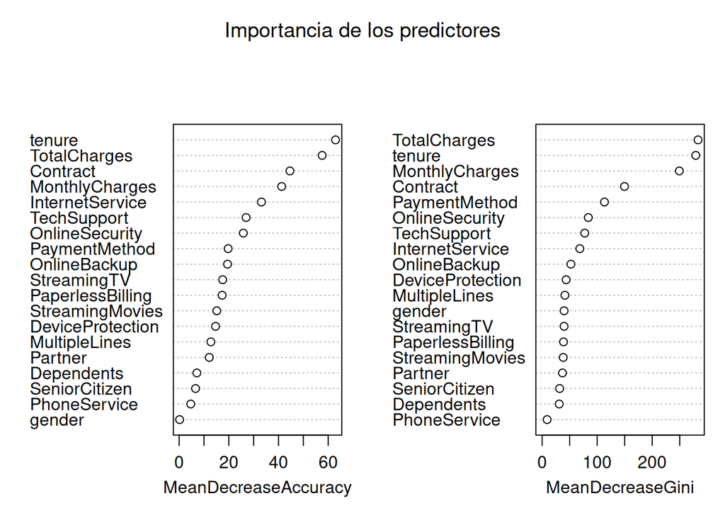

```r
# Gráfico de importancia
varImpPlot(modelo_rf, main = "Importancia de los predictores")
```

Una vez tenemos creado el modelo, vamos a realizar las predicciones de este. Como el dataset tiene un desbalanceo entre las clases, vamos a utilizar la probabilidad de que el cliente sea desertor a la hora de determinar si es desertor o no. Se va a hacer así ya no solo por el desbalanceo de las clases, sino porque queremos que le modelo tienda más a clasificar como desertor que como no desertor, ya que desde el punto de vista comercial es más beneficioso clasificar bien los desertores a pesar de clasificar mal los no desertores. Una vez tengmaos las predicciones hechas, vamos a crear unas matrices de confusión para ver el rendimiento del modelo.

```r
# Calculamos la frecuencia de Churn  = "Yes"
prob.churn.1 <- sum(data.train$Churn == "Yes") / nrow(data)

# Matriz de confusión
predicted.classes_rf <- ifelse(predictions_rf > prob.churn.1, 1, 0)
confusion_matrix_rf <- table(data.test$Churn, predicted.classes_rf)

# Tabla de frecuencias de la variable Churn en el dataset de test
round(prop.table(table(data.test$Churn)), 4) * 100
```

```
##
##    No   Yes
## 73.49 26.51
```

```r
# Matriz de confusión
round(addmargins(prop.table(confusion_matrix_rf)), 4) * 100
```

```
##      predicted.classes_rf
##            0      1    Sum
##   No   49.82  23.67  73.49
##   Yes   6.04  20.47  26.51
##   Sum  55.86  44.14 100.00
```

```r
# Matriz de confusión con margen en columnas
round(addmargins(prop.table(confusion_matrix_rf, 2), 1), 4) * 100
```

```
##      predicted.classes_rf
##            0      1
##   No   89.19  53.62
##   Yes  10.81  46.38
##   Sum 100.00 100.00
```

```r
# Matriz de confusión con margen en filas
round(addmargins(prop.table(confusion_matrix_rf, 1), 2), 4) * 100
```

```
##      predicted.classes_rf
##            0      1    Sum
##   No   67.79  32.21 100.00
##   Yes  22.79  77.21 100.00
```

Una vez que tenemos el modelo y vemos cómo funciona, vamos a analizar las variables más importantes para el modelo. Lo que se quiere conseguir analizando estas variables es ver cuál es el perfil de los desertores y cuál es el de los no desertores. Para poder analizar correctamente el perfil de los desertores vamos a seleccionar las 5 variables más importantes.

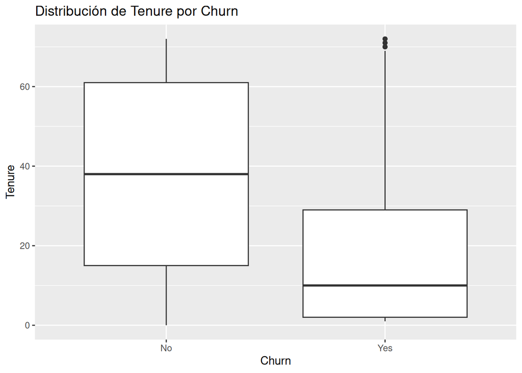

```r
# Seleccionamos las cinco variables más importantes
significant.predictors <- importance(modelo_rf)[order(importance(modelo_rf)[, 2], decreasing = TRUE), ][1:5, 2]

# Creamos un dataframe con la variable desertores y las variables más importantes
data.significant <- data[, c("Churn", names(significant.predictors))]

# Como primer análisis vamos a realizar un boxplot para las variables numéricas y un barplot para las categóricas.
# Las variables numéricas son: "tenure".
# Las variables categóricas son: "Contract", "TechSupport", "OnlineSecurity", "InternetService".

# Tenure
plot1 <- ggplot(data.significant, aes(x = Churn, y = tenure)) +
    geom_boxplot() +
    labs(title = "Distribución de Tenure por Churn", x = "Churn", y = "Tenure")
grid.arrange(plot1)
```

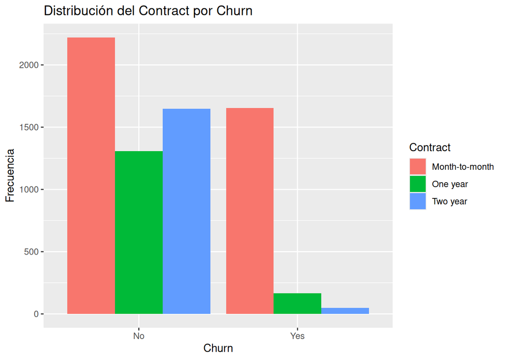

```r
# Contract
plot2 <- ggplot(data.significant, aes(x = Churn, fill = Contract)) +
    geom_bar(position = "dodge") +
    labs(title = "Distribución del Contract por Churn", x = "Churn", y = "Frecuencia")
grid.arrange(plot2)
```

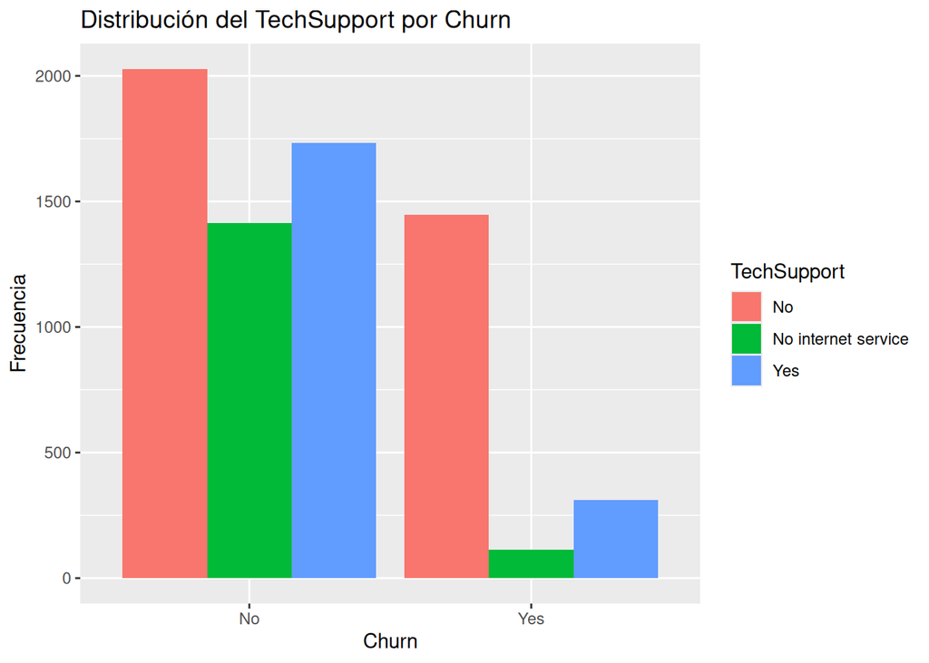

```r
# TechSupport
plot3 <- ggplot(data.significant, aes(x = Churn, fill = TechSupport)) +
    geom_bar(position = "dodge") +
    labs(title = "Distribución del TechSupport por Churn", x = "Churn", y = "Frecuencia")
grid.arrange(plot3)
```

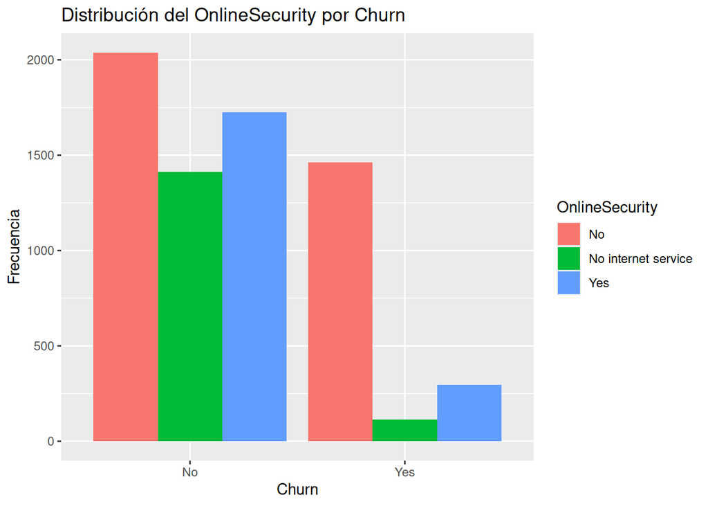

```r
# OnlineSecurity
plot4 <- ggplot(data.significant, aes(x = Churn, fill = OnlineSecurity)) +
    geom_bar(position = "dodge") +
    labs(title = "Distribución del OnlineSecurity por Churn", x = "Churn", y = "Frecuencia")
grid.arrange(plot4)
```

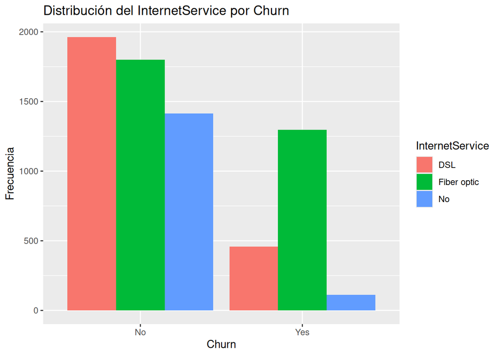

```r
# InternetService
plot5 <- ggplot(data.significant, aes(x = Churn, fill = InternetService)) +
    geom_bar(position = "dodge") +
    labs(title = "Distribución del InternetService por Churn", x = "Churn", y = "Frecuencia")
grid.arrange(plot5)
```

Vamos a analizar las diferentes variables una a una:

- **Tenure**: En el caso de los desertores la permanencia media es de unos 10 meses, pudiendo variar desde cerca de 0 hasta 30 meses en los cuartiles. En el caso de los no desertores la permanencia media está sobre los 38 meses, con un rango de 15 a 61 meses en los cuartiles.
- **Contract**: En el caso de los desertores la gran mayoría tienen un contrato mensual. Por otro lado, en los no desertores aunque la mayoría tenga un contrato mensual también hay una gran parte que tiene un contrato anual o bianual.
- **TechSupport**: En el caso del soporte técnico, la mayoría de los desertores no tienen este soporte. Sin embargo, en los no desertores aunque la mayoría no lo tiene es poca la diferencia con los que sí lo tienen o los que no tienen servicie de internet.
- **OnlineSecurity**: En el caso de los desertores la mayoría no tiene Seguridad Online contratada. Por otro lado, en los no desertores aunque la mayoría no lo tiene también hay una gran parte que sí lo tiene o que no tiene servicio de internet.
- **InternetService**: En el caso de los desertores la mayoría usan fibra óptica, con bastante diferencia hacia los otros servicios. Sin embargo, en los no desertores la mayoría usan DSL, aunque también hay una gran parte que usa fibra óptica o que no tiene servicio de internet.

Ahora que hemos analizado los cinco factores más importantes podemos saber que el perfil de los desertores es el siguiente:

- **Tenure**: De hasta 30 meses, pero centrándonos sobre los 10 meses.
- **Contract**: La mayoría tienen un contrato mensual.
- **TechSupport**: La mayoría no tienen soporte técnico.
- **OnlineSecurity**: La mayoría no tienen Seguridad Online.
- **InternetService**: La mayoría tienen fibra óptica.